# GITHUB:https://github.com/Arravee/Final-Project-5509

# CREDIT CARD FRAUD DETECTION

The data we will be analyzing in this project will be "Credit Card Fraud Detection" and can be found here: https://www.kaggle.com/datasets/mlg-ulb/creditcardfraud?resource=download. This data (148 Mb) is from September 2013 and contains data involving 284,807 credit card transactions of European cardholders and is utilized for fraud detection. With nearly 400,000 cases of credit card fraud in 2020 according to Intuit, a company that specializes in financial software, this is a growing subfield of machine learning and AI that has a huge impact on our daily lives. Utilizing the variables from the dataset and the supervised learning methods reviewed in this course this project seeks to use detect and correctly classify cases of fraud with high precision. The data set has already gone through Principal Component Analysis (PCA) so that the data labels can be generalized. This is so, people who utilize the data do not reverse-engineer the identities and personal credit card info of those involved in the transactions recorded.

```python
import pandas as pd
import matplotlib.pyplot as plt
import numpy as np
import math
import requests
```

### Importing and Cleaning the Data

```python
df = pd.read_csv('creditcard.csv') #read in the csv file
```

```python
print(df.head())
```

```
   Time        V1        V2        V3        V4        V5        V6        V7  \
0   0.0 -1.359807 -0.072781  2.536347  1.378155 -0.338321  0.462388  0.239599
1   0.0  1.191857  0.266151  0.166480  0.448154  0.060018 -0.082361 -0.078803
2   1.0 -1.358354 -1.340163  1.773209  0.379780 -0.503198  1.800499  0.791461
3   1.0 -0.966272 -0.185226  1.792993 -0.863291 -0.010309  1.247203  0.237609
4   2.0 -1.158233  0.877737  1.548718  0.403034 -0.407193  0.095921  0.592941

         V8        V9  ...       V21       V22       V23       V24       V25  \
0  0.098698  0.363787  ... -0.018307  0.277838 -0.110474  0.066928  0.128539
1  0.085102 -0.255425  ... -0.225775 -0.638672  0.101288 -0.339846  0.167170
2  0.247676 -1.514654  ...  0.247998  0.771679  0.909412 -0.689281 -0.327642
3  0.377436 -1.387024  ... -0.108300  0.005274 -0.190321 -1.175575  0.647376
4 -0.270533  0.817739  ... -0.009431  0.798278 -0.137458  0.141267 -0.206010

        V26       V27       V28  Amount  Class
0 -0.189115  0.133558 -0.021053  149.62      0
1  0.125895 -0.008983  0.014724    2.69      0
2 -0.139097 -0.055353 -0.059752  378.66      0
3 -0.221929  0.062723  0.061458  123.50      0
4  0.502292  0.219422  0.215153   69.99      0

[5 rows x 31 columns]
```

```python
df.info()
```

```
<class 'pandas.core.frame.DataFrame'>
RangeIndex: 284807 entries, 0 to 284806
Data columns (total 31 columns):
 #   Column  Non-Null Count   Dtype
---  ------  --------------   -----
 0   Time    284807 non-null  float64
 1   V1      284807 non-null  float64
 2   V2      284807 non-null  float64
 3   V3      284807 non-null  float64
 4   V4      284807 non-null  float64
 5   V5      284807 non-null  float64
 6   V6      284807 non-null  float64
 7   V7      284807 non-null  float64
 8   V8      284807 non-null  float64
 9   V9      284807 non-null  float64
```

[output cut: 23 more lines]

```python
#Check for non-standard null values
a = [np.nan, None, [], {}, 'NaN', 'Null','NULL','None','NA','?','-', '.','', ' ', '   ']
for c in df.columns:
    string_null = np.array([x in a[2:] for x in df[c]])
    print(c, df[c].isnull().sum(), string_null.sum())
```

```
Time 0 0
V1 0 0
V2 0 0
V3 0 0
V4 0 0
V5 0 0
V6 0 0
V7 0 0
V8 0 0
V9 0 0
V10 0 0
V11 0 0
V12 0 0
V13 0 0
V14 0 0
V15 0 0
V16 0 0
V17 0 0
V18 0 0
V19 0 0
V20 0 0
V21 0 0
V22 0 0
V23 0 0
V24 0 0
V25 0 0
V26 0 0
V27 0 0
V28 0 0
Amount 0 0
Class 0 0
```

### Visualizing the Data

Now we can move on to visualizing the data. First, we want to look at a correlation matrix, because while the PCA was performed it would still be useful to utilize this information to determine the model we are going to use.

Individually, we are most interested in looking at two columns, Amount and Class. We expect Class to have a very small amount of "1" values. This is because while there are hundreds of thousands of instances of credit card theft, the number of legitimate transactions heavily outnumber the fraudulent transactions. We also want to compare a graph of Amount, as we expect there to be few high-value transactions as most day-to-day transactions are relatively small.

```python
import seaborn as sns
```

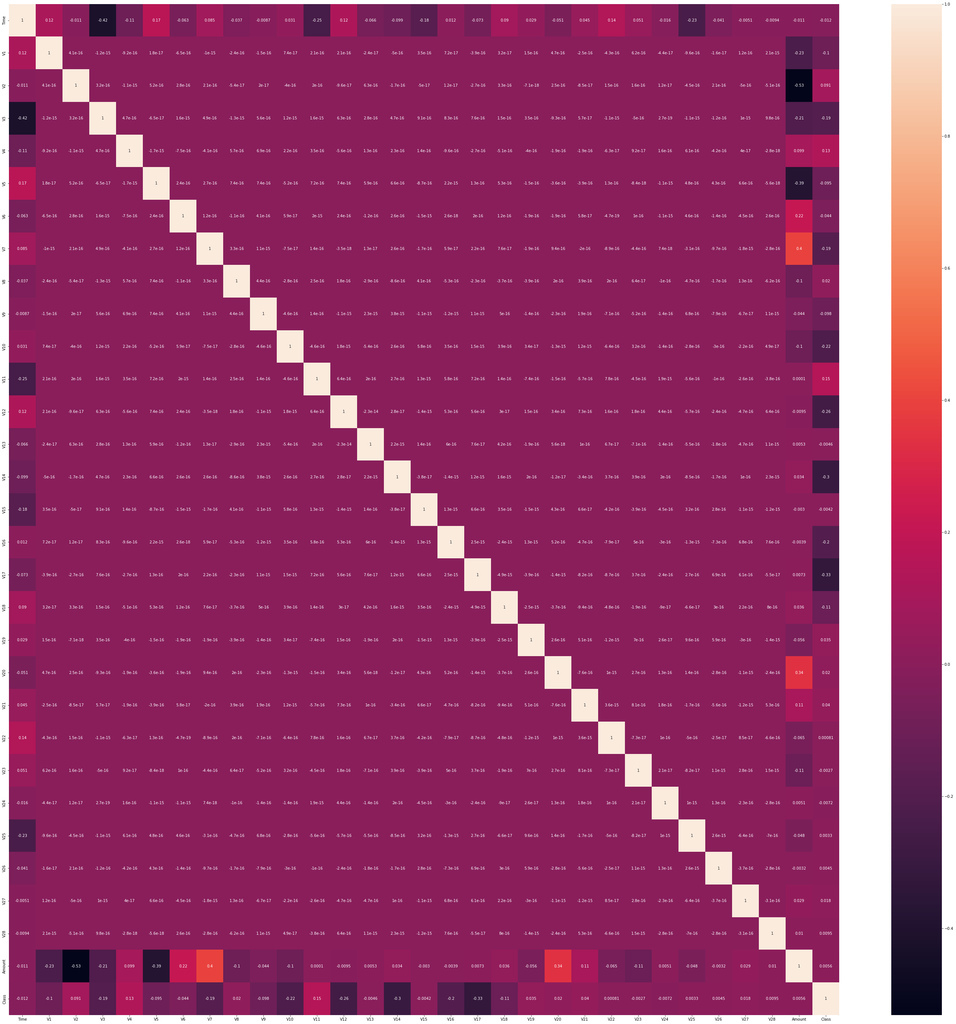

```python
corrMatrix = df.corr()
plt.figure(figsize = (50,50))
sns.heatmap(corrMatrix, annot=True)
```

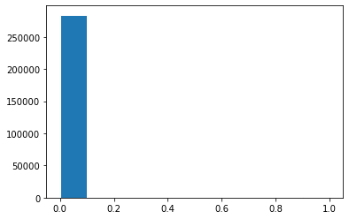

```python
class_list = df["Class"].tolist()
fig, ax = plt.subplots()

ax.hist(class_list, edgecolor="white")
```

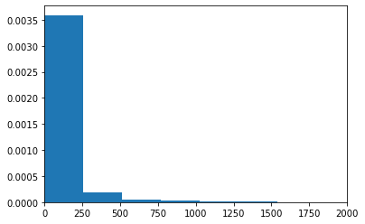

```python
amount_list = df["Amount"].tolist()

plt.xlim(0, 2000)
plt.hist(amount_list, density=True, bins=100)
```

```python
df['Class'].value_counts()
```

```
0    284315
1       492
Name: Class, dtype: int64
```

Looking at our class data we see what we predicted. A very small amount of frauds are in this dataset. This means we can not simply split the data randomly. Instead, we must make sure as we are splitting the data to make sure some of the training data does contain fraudulent cases.

### Splitting the Data

To split our data we are using undersampling. Undersampling refers to a group of techniques used to balance the distribution for a skewed classification dataset by removing examples from the training dataset that belong to the majority class. As seen in the counts output above our data is heavily skewed towards legitimate transactions (df['Class'] == 0). To accomplish this, we will "resample" the data by having only 3 times as many legitimate transactions as fraudulent transactions. We start by separating out the predictors and response variables. Then we randomly choose the index values for the legitimate transactions utilizing the np.random.choice() method. If we desire to we can change the proportion of legitimate to fraud from 3:1 to 5:1 or greater by simply changing the number_fraud variable. Then we take the selected indexes, create a new data frame from said indices and run the train_test_split method that we have used in class.

```python
X = df.iloc[:, df.columns != 'Class']
y = df.iloc[:, df.columns == 'Class']
len(y[y.Class ==1])
```

```
492
```

```python
number_fraud = len(df[df['Class']==1]) * 3
fraud_index = np.array(df[df['Class']==1].index)
legit_index = np.array(df[df['Class']==0].index)

random_legit_index = np.random.choice(legit_index, number_fraud, replace = False )
under_sample_index = np.concatenate([fraud_index, random_legit_index])
```

```python
#Make sure they don't overlap
np.intersect1d(fraud_index , legit_index)
```

```
array([], dtype=int64)
```

```python
under_sample = df.iloc[under_sample_index,:]
x_undersample = under_sample.iloc[:, under_sample.columns != 'Class'];
y_undersample = under_sample.iloc[:, under_sample.columns == 'Class'];
```

```python
from sklearn.model_selection import train_test_split
X_train_under, X_test_under, y_train_under, y_test_under = train_test_split (x_undersample,y_undersample, test_size = 0.3, random_state = 42)
```

```python
y_train_under['Class'].value_counts()
```

```
0    1035
1     342
Name: Class, dtype: int64
```

### Modelling the Data and Results

We have a few options to model our data both from this course and outside of it. Due to the large number of predictor variables we will eliminate ourselves from using standard decision trees and K-nearest neighbor. In a similar vein, we will stay away from SVMs due to the large dataset involved.

We have also chosen to stay away from Logistic Regression and Multilinear Regression, as we cannot readily suppport an assumption of linearity between the variables.

Our three types of Models that we are going to look at are Naive Bayesian and Random Forest.

```python
from sklearn.naive_bayes import GaussianNB
from sklearn.ensemble import RandomForestClassifier
from datetime import datetime
from sklearn.metrics import confusion_matrix, recall_score
from sklearn.metrics import plot_confusion_matrix
```

```python
start_time = datetime.now()


clf_nb = GaussianNB()
clf_nb.fit(X_train_under, y_train_under.values.ravel())
y_pred_nb = clf_nb.predict(X_test_under)

end_time = datetime.now()
print('Duration: {}'.format(end_time - start_time))
```

```
Duration: 0:00:00.005505
```

```python
cm_nb = confusion_matrix(y_test_under, y_pred_nb)
recall_nb = recall_score(y_test_under,y_pred_nb)
print(recall_nb)
```

```
0.7266666666666667
```

```python
#Checking recall value
tn, fp, fn, tp = cm_nb.ravel()
print(tp, fn)
```

```
109 41
```

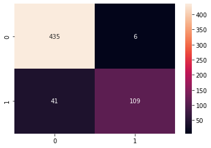

```python
sns.heatmap(cm_nb, annot=True, fmt='g')
```

```python
start_time_rf = datetime.now()

clf_rf = RandomForestClassifier(max_depth=2, random_state=0)
clf_rf.fit(X_train_under, y_train_under.values.ravel())
y_pred_rf = clf_rf.predict(X_test_under)

end_time_rf = datetime.now()
print('Duration: {}'.format(end_time_rf - start_time_rf))
```

```
Duration: 0:00:00.233200
```

```python
cm_rf = confusion_matrix(y_test_under, y_pred_rf)
recall_rf = recall_score(y_test_under,y_pred_rf)
print(recall_rf)
```

```
0.8466666666666667
```

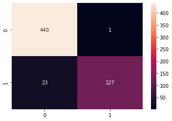

```python
sns.heatmap(cm_rf, annot=True, fmt='g')
```

```python
start_time = datetime.now()

clf_rf_deep = RandomForestClassifier(max_depth=10, random_state=12)
clf_rf_deep.fit(X_train_under, y_train_under.values.ravel())
y_pred_rf_deep = clf_rf_deep.predict(X_test_under)

end_time = datetime.now()
print('Duration: {}'.format(end_time - start_time))
```

```
Duration: 0:00:00.448384
```

```python
cm_rf_deep = confusion_matrix(y_test_under, y_pred_rf_deep )
recall_rf_deep = recall_score(y_test_under,y_pred_rf_deep )
print(recall_rf_deep)
```

```
0.8866666666666667
```

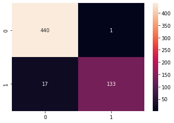

```python
sns.heatmap(cm_rf_deep, annot=True, fmt='g')
```

```python
from sklearn.neural_network import MLPClassifier
from sklearn.preprocessing import StandardScaler
```

```python
# scaler = StandardScaler()
# X_train = scaler.fit(X_train_under)
# X_test = scaler.transform(X_test_under)
```

```python
# start_time = datetime.now()

# MLPC = MLPClassifier(hidden_layer_sizes=(500,), max_iter=10000)
# MLPC.fit(X_train_under, y_train_under.values.ravel())
# y_pred_nn = MLPC.predict(X_test_under)

# end_time = datetime.now()
# print('Duration: {}'.format(end_time - start_time))
```

```python
# cm_nn = confusion_matrix(y_test_under, y_pred_nn)
# recall_nn = recall_score(y_test_under,y_pred_nn)
# print(recall_nn)
```

### Analysis

In our results, we displayed the confusion matrices and two variables: model run-time and the recall score. Each of these is significant. The run-time of the model is important as we want to notify the cardholder in a timely manner, via text or email, of fraudulent transactions involving their card. The recall score is important because we are focusing on capturing fraudulent transactions. We are not too concerned with falsely assuming a legitimate transaction is fraudulent. This is because an extra text/email is a minor inconvenience when compared to the alternative of not catching and alerting the consumer to actual credit card fraud.

From our results, we can see that the Gaussian Naive Bayes model has a significantly faster runtime but has an extremely poor recall score. The Random Forest Model while slower has a much better recall score than the two and what we notice above is that increasing the max_depth from 2 to 10, doubles the time while increasing the score by .04. This is extremely important as a runtime within a second is still fast enough to alert the cardholder in a timely manner, however, the score is still a bit too low.

To improve the performance of the model, instead of simply continuing on with Random Forest, we looked into Neural Networks. This is not without grounds. There has been active research into the application of neural networks, and one such paper can be found here: https://www.sciencedirect.com/science/article/pii/S2666285X21000066#. However, we quickly ran into an issue, it was extremely volatile (as demonstrated below). Currently, the usage of a neural network in this project will require significantly more time and research, however, we believe it is the optimal path going forward as at times our network has produced recall scores of .99 with an insignificant increase in run-time when compared to our other models.

```python
time_nn = []
recall_nn = []

for i in range(10):

    start_nn = datetime.now()

    MLPC = MLPClassifier(hidden_layer_sizes=(300,), max_iter=10000)
    MLPC.fit(X_train_under, y_train_under.values.ravel())
    y_pred_nn = MLPC.predict(X_test_under)

    end_nn = datetime.now()
    time_nn.append(end_nn - start_nn)
    cm_nn = confusion_matrix(y_test_under, y_pred_nn)
    recall_nn.append(recall_score(y_test_under,y_pred_nn))
```

```python
time_seconds = []

for i in range(len(time_nn)):
    time_seconds.append(time_nn[i].microseconds/1000000)

print(time_seconds)
```

```
[0.455391, 0.374322, 0.449385, 0.53596, 0.391836, 0.234201, 0.249714, 0.169645, 0.68809, 0.286746]
```

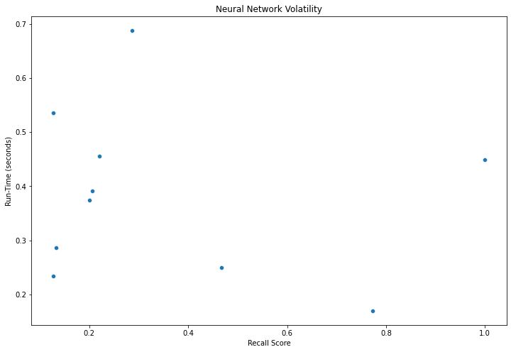

```python
fig = plt.gcf()

fig.set_size_inches(12, 8)


sns.scatterplot(x = recall_nn, y = time_seconds)

plt.title('Neural Network Volatility')
plt.xlabel('Recall Score')
plt.ylabel('Run-Time (seconds)')
```

### Conclusion

To summarize, in this project we used supervised learning techniques to identify credit card fraud. This in turn can be used to alert the consumer of said fraud so they can take the appropriate actions in response. We explored an approach using Naive-Bayes and Random Forests where we saw a significant difference in execution time as well as recall score. After looking at these results we did more research and attempted to utilize neural networks but found the results to be extremely volatile. We believe this has to do with the default solver, alpha, and/or the number of data points itself and we also believe this is the most likely path for success in our three approaches as the recall score for Random Forests will eventually plateau while consuming significant resources. Ideally, this project will be one in a series as we seek to improve the performance of our detection system to better help the consumer.